# Epidemic spreading processes

We'll now turn to one of the most important, interesting, and applicable applications of complex networks and complex processes: the study of epidemics. An epidemic is a process: it runs over a network substrate, and its behaviour is affected by the network's topology and other factors. It turns out that the mathematics of many processes can be modelled in this way: disease epidemics, obviously, but also the spread of rumours, information, and disinformation; computer viruses; panics and other financial dislocations; and so forth.

In this chapter we'll discuss epidemiology "in the wild" as conducted by epidemiologists. We'll explore the non-networked approaches and show their limitations, and then map them into the domain of complex networks to show how networks can improve modelling.

## Epidemiology for beginners

Before we start looking at epidemics on networks, we need to understand something of about the science of epidemics in the real world: *epidemiology*.

Epidemiology is usually studied as part of medicine, but in reality it has two branches. There is *clinical epidemiology* that studies disease outbreaks in the wild, essentially as a tool of treatment and of public health; and there is *theoretical* or *mathematical epidemiology* that explores the abstract processes that underlie disease propagation (and indeed many other propagation prcesses, which turn out to share a common mathematical form). Epidemic spreading on networks is clearly abstracted mathematical epidemiology, but it helps to understand the clinical side at least a little in order to get a handle on the processes webeing abstracted.

### Diseases

[figure not shown]

Periods in the progression of a "typical" disease.

A person's infection goes through several periods. Once infected, the disease resides **latent** in their system, not showing symptoms and not being infectious to others. After this latent period the disease becomes infectious, capable of being spread to others: this is the **infectious** period. Typically a person's infectiousness peaks and dies away before the end of the disease progression.

These two periods – latent and infectious – control the *transmission* of infection. After initial infection, however, there is an **incubation** period before the person shows symptoms of the disease. After the onset of symptoms, the disease progresses and ends in some **resolution**: the patient gets better, or dies. If they recover, they may then have some immunity to further infection.

[figure not shown]

Different disease types.

For different diseases, the lengths of these periods and the ways they overlap vary. For **Type A** diseases, the incubation period is longer than the latent period. This means that a patient can start to transmit the disease before the disease becomes manifest in themselves. This happens in cases of measles. In **Type B** diseases such as ebola, by contrast, the incubation period is shorter than the latent period, meaning that asymptomatic patients cannot infect others. So despite ebola being a more feared disease than measles, it may be easier to treat epidemiologically since quarantining patients showing symptoms will prevent transmission in the general population (although not to medical staff); in measles, transmission starts before symptoms show themselves, so quarantine is less effective. Moreover the infectious period may continue after the patient has died: the corpses of victims of diseases such as ebola that are transmitted *via* bodily fluids can be extremely infectious for some time after death, meaning that funerals become very dangerous loci of potential infection for mourners.

How long do the different periods last? For each disease there will be typical durations, often with substantial variance. In the case of ebola, for example, a typical timeline would be a 0–3 day incubation period, a 7–12 day progression to recovery or death, and a latent period of 2–5 days. The ranges give the variance of periods, different for different individuals that depend on factors including the severity of infection and the individual's overall health. However, the incubation period for ebola can be up to 21 days, meaning that a suspected case needs to be quarantined for this period: long enough, in other words, for the disease symptoms to manifest if the person is actually infected. While one can test for most diseases (including ebola) in a laboratory, during an epidemic such tests may overwhelm the public health infrastructure, making quarantine the most practical option. (During historical disease outbreaks, of course, quarantine was the *only* option.)

### Measuring epidemics

Epidemiology consists of creating models of diseases and their spread than can be analysed, to make predictions or to simulate the effects of different responses. To do this, we need to identify the core elements of a disease from the perspective of transmission: we do *not* need to understand the disease's biology, only the timings and other factors that affect its spread.

We discussed above the periods of diseases, their relationships, and their different, often characteristics, periods and variances. We need some other numbers as well, however, and it turns out that these can be measured directly in the field.

The fist important number is known as the **secondary attack rate**, denoted 2°AR. This measures what proportion of people exposed to each for each primary case will develop infection. For example in the first ebola outbreak 498 family members were exposed to infected relatives, of whom 38 developed ebola themselves. This gives a 2°AR of $38 / 498 = 7.6\%$.

There are a couple of caveats with this number. Firstly, 2°AR only applies to small populations, typically villages: it doesn't scale-up to whole populations. Secondly, 2°AR is very context-sensitive and depends on the degree of contact that individuals have with the infected individual: for close family members, the 2°AR in the first ebola outbreak was around 27% rather than around 8%. Thirdly, individuals may become increasingly infectious as their own infection progresses. Fourthly, disease organisms are subject to natural selection and, since they reproduce quickly, can vary in their infectiousness over time. The selection pressures often lead to diseases become progressively more transmissible but less severe, eventually become sufficiently weak for immune systems to be able to cope with them directly – and the epidemic dies out.

The second important metric is the **basic case reproduction number**, denoted $R_0$. $R_0$ represents the total number of secondary infections expected for each primary infection in a totally susceptible population. The $0$ in $R_0$ stands for $t = 0$: the basic case reproduction number applies at the start of an epidemic. Over time, the number of people susceptible to infection will vary as they become infected, recover, die, and so forth. We can account for this by developing a **net case reproduction number** $R_t$ by multiplying $R_0$ by the susceptible fraction of the population at time $t$.

$R_0$ is affected by three factors:

1. The duration of infectiousness. All other things being equal, a disease with a longer period of infectiousness has more time in which to infect other patients.
2. The probability of transmission at each contact. Some diseases are extremely contagious, with each contact having a high probability of passing on the infection; others are much harder to pass one to secondary cases.
3. The rate of contact. Someone coming into contact with a lot of susceptible individuals will have more opportunities to generate a secondary case than someone meeting fewer people.

The first two factors are characteristic of the disease, derived from its biology. The third is affected by the social conditions in which the epidemic takes place: it is this factor that quarantine affects, by reducing (to zero) the contacts an infected person has with others.

These two metrics, 2°AR and $R_0$, are related. If we compute 2°AR for the different circumstances of contact – family, neighbours, community, and so forth – and multiply each by the number of contacts a person has in each circumstance, we can sum them to get $R_0$:

\begin{align} R_0 &= 2^oAR_{family} \times contacts_{family} \\ &+ 2^oAR_{neighbours} \times contacts_{neighbours} \\ &+ 2^oAR_{community} \times contacts_{community} \\ &+ \cdots \end{align}

As with disease periods, $R_0$ is an average that is affected by various factors and is best treated as a mean value with some variance: some infected individuals will affect more people, some less, but *on average* they will generate $R_0$ secondary infections.

### Controlling epidemics

The importance of $R_0$ is that it indicates whether, and how fast, a disease can spread through a susceptible population. If $R_0 < 1$ then we expect fewer than one secondary case per primary, and the disease will die out quickly. If $R_0 = 1$ then the disease will perpetuate itself in whatever size of population was originally infected. Nature is never so precise, so we'll never encounter a disease like this. However, $R_0 = 1$ is the *threshold value* about which diseases become epidemics. If $R_0 > 1$, the disease will break-out and infect more and more people exponentially quickly. Exactly *how* quickly depends on how large $R_0$ is. For measles, $R_0 \ge 15$ – fifteen new infections for each case – which explains how measles spread so quickly in unvaccinated populations. Different strains of influenza have $1.5 \le R_0 \le 3$. (If this sounds benign, remember that the [1918 "Spanish flu" epidemic](https://en.wikipedia.org/wiki/1918_flu_pandemic) killed more people than the First World War.) Perhaps interesting in light of its media coverage, for ebola we have $1.2 \le R_0 \le 1.8$, roughly the same as a not-too-severe winter flu outbreak.

In order to bring an epidemic under control, then, we need to reduce the *effective* value of $R_0$. This will generally happen anyway through mutation and selection as the disease agent (typically a bacterium or a virus) evolves. We can quarantine infected individuals so that they do not cause further secondary infections. This is clearly more effective with Type B diseases than with Type A, since the latter will have already become infectious before they become symptomatic.

A more effective approach is to reduce the susceptible fraction of the population. The approach is to make the value of $R_t$ less than one (the epidemic threshold) so that the disease dies out naturally. This happens naturally in diseases to which individuals have natural or acquired immunity, for example by surviving a bout of the disease.

An even more effective approach is to artificially give people immunity: vaccination. A vaccine, where it exists, confers full or partial immunity on its recipients. How many people do we need to vaccinate? If we have a disease with $R_0 = 3$, then to get the $R_t$ below the threshold we we would need to vaccinate $(3 - 1) / 3 = 67\%$ of the population. This value 67% is the **herd immunity threshold** for the disease: if we vaccinate above this fraction of the population, the effective value of $R_0$ should there be an outbreak will be less than one, and the outbreak will die out.

Actually things are a little more complicated. Vaccines are not 100% effective. We can define the **vaccine efficacy rate** $VE$ as:

$$ VE = \frac{rate_{unvaccinated} - rate_{vaccinated}}{rate_{unvaccinated}} $$

where $rate_{unvaccinated}$ and $rate_{vaccinated}$ are respectively the number of people who catch the disease when (un)vaccinated. We factor this into the herd immunity threshold calculation from above: if $VE = 90\%$ then we need to vaccinate $0.67 / 0.9 = 74\%$ of the population to get herd immunity while accounting for the vaccine's limited efficacy.

### Non-uniformity or inhomogeneity

The above discussion is based on one vital assumption, that of **random** or **homogeneous mixing**. When we talk about rates of infection of the herd imunity threshold, we are implicitly talking about a very simple and even situation in which everyone potentially infects everyone else who is susceptible. This clearly isn't what happens in practice. Measles outbreaks, for example, typically rip through schools but not whole towns, because children are in closer proximity to other children that to the general population. (Using the terminology from above, the 2°AR for classmates is higher than for other classes of people.) The population is **inhomogeneous**.

There are other sources of non-uniformity. Some people may meet far more people than others, which means that (if susceptible) they have more chances of being infected, and (if infected) have more opportunities to pass on the disease. Vaccinating or otherwise protecting such people preferentially might have more of an effect than trying to get herd immunity through largely random vaccination. In reducing sexually transmitted diseases, for example, the most efficient strategy is often to target sex workers since they have disproportionately more sexual partners than average.

There will also be people who for whatever reason are not, or cannot be, vaccinated: perhaps they have an allergy to the vaccine, or are too young for it, or too old, or have some objection to taking it. Herd immunity protects these groups by reducing the chances that an infection starting somewhere in the population will spread as far as them and get the opportunity to infect them. Sometimes one finds clusters of unvaccinated people (retirement homes, for example) in which disease outbreaks are unusually severe regardless of whether the population as a whole has herd immunity. This is a direct consequence of inhomogeneous mixing, with an infected person being far more likely that average to encounter an unvaccinated individual in such a setting.

As a general rule, "small" populations can safely be treated as homogeneous, while "large" populations are inhomogeneous. What exactly constitutes "small" and "large" is a tricky question.

### Chains of infection and contact tracing

What does a spreading epidemic look like? If we begin with the first infected person – **case zero** of the epidemic – then that person infects some number $R_0$ of individuals (with some variance). Each of those people then causes $R_0$ tertiary infections, and so on: an exponential increase in infected individuals.

Like all exponential processes in nature, this one does not go on for ever. What "fuels" the epidemic is the availability of susceptible individuals, and eventually the supply runs short, there are no susceptible people to infect, $R_t$ drops below one, and the epidemic dies out. In a homogeneous population, shortage of susceptibles is a *global* phenomenon: the proportion of susceptible people drops as a whole. In an inhomogeneous population, however, it may be a *local* phenomenon: there may be lots of susceptible people in the population as a whole, but if there are none locally to be infected, the disease can still die out.

Each infected person is infected by *someone*, and only one person. If we were to look at the way the infection spreads, the infected cases would form a tree whose root was case zero and whose levels were formed by secondary cases, tertiary cases, and so on. There is a **chain of infection** from each infected person back to case zero.

In clinical epidemiology, constructing these chains of infection is the process of **contact tracing**. When a new case is discovered (or suspected), public health workers try to track down everyone that person has met since they became infectious and test them to see of they are infected: if so, they can be treated, and their own contacts traced. The chains of infection form a tree, with the case-zero individual at the root.

## Modelling epidemics

Now we've looked at the basics of epidemiology, we can think about how this translates into network science. Essentially what we're looking for is a way to abstract the *physical* process of disease transmission into a *mathematical* process we can analyse and/or a *simulation* process we can simulate.

From a clinical perspective, infection spreads by some appropriate physical contact. It might be proximity to an infected person's bodily fluids; breathing-in infectious particles like viruses or spores; touching some surface that's been touched by an infected person; coming into contact with an animal that can pass infection to humans; or some combination of all of these. Clearly the detailed mechanisms involved are vitally important, since they suggest countermeasures that can be taken to reduce the spread of infection and help identify those measures that *won't* reduce it: wiping-down and disinfecting surfaces will only be effective if that is a vector of transmission ofr the disease in question, for example.

We have several options in capturing these dynamics. For example,

- We could capture the *rates* at which people move between the various stages of disease and build these rates into a *deterministic* and *macroscopic* dynamical system covering an entire population;
- We could model the infection dynamics of each pair of individuals, leading to a *stochastic* and *microscopic* simulation;
- Alternatively, we could take the population as a whole and model the times between different events (infection, recovery, and so on), leading to systems that are *stochastic* and *macroscopic*
- Or we could use a slightly different approach and model the number of events occurring in a particular time, again giving us a *stochastic* and *macroscopic* system

The first is typically done in a non-networked manner, and we'll look at this first: it provides a baseline for our understanding of diseases, and illustrates the key ideas. We'll then look at the other three with a view to simulating them over networks.

But before do any of this, we need to develop a more abstract view of diseases.

### SIS, SIR, and all that: Compartmented models of disease

When we talked about diseases above, we talked in epidemiological terms about the latent period, infectious period, and so forth. These are standard clinical terms, but not ones that are used in the theoretical study of diseases. Instead, we model diseases using various models that focus on the state of a patient at any given time.

In everyday life, when we discuss diseases we tend to talk about being being infected, having been infected, being immune, and so forth. We can think of these terms as *compartments*: "buckets" into which we drop individuals depending on their disease state. A person can move between compartments as the epidemic progresses, for example becoming infected and then perhaps recovering (or dying). The ways in which we set up the compartments and the ways and rates at which people in the population under study move between them, form *compartmented models* of disease.

The simplest compartmented model is for diseases like the common cold. Medically, there is nothing simple about the common cold, hence it's resistance to attempts to control it; but we can abstract is mathematically very simply by saying that an individual starts out *susceptible* to a cold, then becomes *infected*, and after some time spent sneezing and generally transmitting the disease recovers but becomes susceptible to further infection. If we denote a susceptible individual by S and an infected one by I, a typical infectious trajectory will be from S, to I, and then to S again. We term this the *SIS model* of infection.

A lot of diseases don't behave like this, however: having been infected, an individual may die, or may recover and become immune to further infection. In some sense these two outcomes are the same, in that the individual – whether dead or recovered – takes no further part in the epidemic. (This immediately shows why one should be careful about mathematical abstraction. The two outcomes are in no way "the same" for the individual concerned.) If we say that a post-infection individual is *removed* from the model, denoted R, then we have an *SIR model*.

We might want to be more specific still and separate the latent period from the infectious period. In this case we might add a new compartment for *exposed* individuals, denoted E, giving an *SEIR model*. Clearly there are a lot of further possibilities too.

For each of these models, we can take a microscopic view and treat the compartments as the states of individuals: each individual is placed in a particular state. Alternatively we can take the macroscopic view and treat the compartments as sub-populations: the number of people in each state. The two views are just different ways of looking at the same data.

## Deterministic, macroscopic: the calculus of epidemic spreading

Epidemic spreading has a long history, and its study pre-dates network science by some time. It's certainly possible to study epidemic spreading in a population using more traditional mathematics: indeed, the first discussion of the SIR model appears in 1927 [KMcK27]. Since the same approach appears in many applications to networks too, we'll discuss it first.

Suppose we have a population of $N$ people. At each time $t$ we divide the population into three sub-populations $s$, $i$, and $r$ corresponding to susceptible, infected, and recovered individuals, so $s + i + r = N$.

An epidemic is a process: it changes with time. Descriing this process means capturing how the values of $s$, $i$, and $r$ change over time – or, to put it another way, $s$ is a function of time, and we want to know how the value of $s(t + 1)$ changes as a function of $s(t)$, $i(t)$, and $r(t)$. It is actually easier to change our view slightly and ask about the difference between values, for example $s(t + 1) - s(t)$. The dynamics then forms a system of difference equations: if we assume that the population is very large, and we compute the population changes at a very fine time resolution, we can instead form a set of ordinary differential equations for which the mathematics is better understood.

How does the population of susceptible nodes change? A node becomes infected (and ceases to be susceptible) when a susceptible and infected nodes are adjacent with probability $\beta$. However, we're simply talking here about a population, with no physical model of where individuals are in relation to each other. What does it mean to be "adjacent", given that we don't have a physical model?

In this simple model we side-step the physical model and make the assumption of *uniform mixing*: every susceptible and infected person that *could* meet, *do* meet in each timestep. That means that every susceptible person at time $t$ meets $i(t)$ infected people, and therefore has $i(t)$ opportunities to become infected with probability $\beta$ at each encounter. There are $s(t)$ susceptible people, so $s(t)$ decreases in proportion to the number of encounters multiplied by the probability that each encounter results in an infection. We can simply convert this to a differential equation:

$$ \frac{ds}{dt} = -\beta i(t) s(t) $$

(The minus sign denotes that the population $s(t)$ is *decreasing* as people become infected.) Similarly, we can describe the evolution of the two other sub-populations. Nodes become infected at a rate proportional to the number of encounters and the probability of infection; nodes recover at a rate proportional to the number of infected individuals and the probability of recovery:

$$ \frac{di}{dt} = \beta i(t) s(t) - \alpha i(t) \hspace{1in} \frac{dr}{dt} = \alpha i(t) $$

The assumption of uniform mixing is clearly a problem for human populations. It might make sense for a small venue where people move around a lot (a nightclub, perhaps), but not a large population like a country or even a smaller population with more restricted movement (the crowd at a football match). Another, slightly different, view is that the parameter $\beta$ actually conflates two issues: the proportion of the possible encounters that actually happen per time step, and the probability that one of these encounters results in infection. These limitation are among the reasons why it is better to model epidemics on networks that capture precisely this neglected structure, allowing $\beta$ to be purely about infection rates (which can be measured empirically).

### Analysing the system

To recap, we have a system of three differential equations in three unknowns:

$$ \frac{ds}{dt} = -\beta i(t) s(t) \hspace{1in} \frac{di}{dt} = \beta i(t) s(t) - \alpha i(t) \hspace{1in} \frac{dr}{dt} = \alpha i(t) $$

We can simplify the system slightly by observing that $r(t) = N - s(t) - i(t)$ and only concern ourselves with the susceptible and infected sub-populations. We can also rescale the three sub-populations to be fractions of the overall population, so that $0 \leq s(t), i(t), r(t) \leq 1$ and $s(t) + i(t) + r(t) = 1$ at all times $t$. (Put another way, $s(t)$ is the probability that a node selected from the population at random at time $t$ will be susceptible.)

We now have two functions $s(t)$ and $i(t)$ and their associated rates of change. We might instead ask how the value of $i(t)$ changes with $s(t)$:

$$ \begin{align*} \frac{di}{ds} &= \frac{di/dt}{ds/dt} \\ &= \frac{\beta i(t) s(t) - \alpha i(t)}{-\beta s(t) i(t)} \\ &= \frac{\alpha}{\beta} \frac{1}{s(t)} - 1 \end{align*} $$

This is a first-order, linear differential equation that we can solve directly:

$$ \begin{align*} i(t) &= \int \left ( \frac{\alpha}{\beta} \frac{1}{s(t)} - 1 \right ) ds \\ &= \frac{\alpha}{\beta} ln(s(t)) - s(t) + c \end{align*} $$

At $t = 0$ the number of infected nodes is typically very small, so $i(0) \approx 0$ and $s(0) \approx 1$, and therefore:

$$ 0 \approx \frac{\alpha}{\beta} ln(1) - 1 + c \approx -1 + c $$

So if we set $c = 1$ we have that $i(s) = \frac{\alpha}{\beta} ln(s(t)) -s(t) + 1$. This is clearly a somewhat awkward equation, having terms in both $s(t)$ and $ln(s(t))$. We can explore it numerically however.

```python
import networkx as nx

import math
import numpy as np
import numpy.random as rnd

import matplotlib
import matplotlib.pyplot as plt
import matplotlib.cm as cmap
import seaborn as sns
%matplotlib inline
%config InlineBackend.figure_format = 'svg'
```

First we build a function $i(s)$ for given values of $\beta$ and $\alpha$:

```python
def make_i( pInfect, pRecover):
    '''Construct a function for infection in terms of susceptibility.

    pInfect: probability of infection per timestep
    pRecover: probability of recovery per timestep
    returns: infection function'''
    def i( s ):
        return (pRecover / pInfect) * math.log(s) - s + 1
    return i
```

(We use `pInfect` for $\beta$ and `pRecover` for $\alpha$.) We can then plot how the population of infected nodes varies with the population of susceptible nodes for different values of these parameters:

```python
fig = plt.figure(figsize = (5, 5))
ax = fig.gca()
plt.xlabel("$s$")
plt.ylabel("$i(s)$")
ax.set_xlim([0.0, 1.0])
ax.set_ylim([0.0, 1.0])

s = np.linspace(0.000001, 1.0, num = 50)
for (pI, pR, pt) in [(0.4, 0.1, 'b.'),
                     (0.3, 0.1, 'r.'),
                     (0.3, 0.05, 'y.'),
                     (0.5, 0.1, 'g.'),
                     (0.5, 0.2, 'k.'),
                     (0.1, 0.05, 'g+')]:
    i = make_i(pI, pR)
    plt.plot(s, map(i, s), pt, label= "$\\beta = %(pI).2f \\quad \\alpha = %(pR).2f$" % { 'pI': pI, 'pR': pR })
plt.legend()

_ = plt.show()
```

[figure not shown]

Looking at these curves we see that they intersect the $i = 0$ axis at a positive value of $s$: that is to say, the number of infected individuals drops to zero when there are still some susceptible individuals left in the population – the epidemic does not infect everyone. It would be nice to know this value analytically, but that turns out to be hard: however, it is clear from the numerical results.

Another useful thing to know is whethet the epidemic will die out rapidly or spread through the population. Since $\beta$ and $\alpha$ are fixed for a particular disease (a particular flu variant hits with a particular virulence and recovery rate), the remaining parameter is the number of infected individuals at the start of the epidemic, $i(0)$. We might therefore ask whether there is a critical value $i_c$, the *epidemic threshold*, above which the epidemic spreads and below which it dies out.

Look at $\frac{di}{dt}$ for a moment. We can re-write this expression as:

$$ \frac{di}{dt} = (\beta s(t) - \alpha) i(t) $$

This is a rate of change that can be less than, equal to, or greater than zero. If it is less than zero, the epidemic is dying out (the number of infected individuals decreases); if it is greater than zero, the epidemic is growing; and there is a separatrix between these two regimes at $\frac{di}{dt} = 0$ the corresponds to the epidemic threshold at $t = 0$. This can occur in two cases:

1. when $i(t) = 0$ and there are no infected people remaining in the population to infect others; and
2. when $\beta s(t) - \alpha = 0$, or when $s(t) = \frac{\alpha}{\beta}$.

$$ i(0) > \frac{\beta - \alpha}{\beta} $$

### SIR on a network

We'll now look at how to simulate epidemic spreading on a network. From the above we know that the purpose of the network is to capture how people interact with each other, and therefore how the encounters that can result in infection are generated. The structure of the network therefore directly affects infection: nodes with high degree will have more potetially infected neighbours and therefore more chances of being infected. The network does not directly affect recovery, as nodes recover with a fixed probability.

To simulate the epidemic we need to specify the network and the way the infection spreads. We can then tie these all together to build a simulation that shows how the infection spreads over time for different values of the infection ($\beta$) and recovery ($\alpha$) parameters.

### The social network

We'll begin by representing the network as a graph in NetworkX. Rather than set up the graph from scratch, we'll assume that it is passed in: that is to say, the people and friendships are acquired somehow, perhaps from a survey or perhaps by generating a random graph. What we need to do is to set up the network with everyone initially susceptible to the disease. We'll do this by attaching an attribute `state` to each node.

```python
SPREADING_SUSCEPTIBLE = 'S'
SPREADING_INFECTED = 'I'
SPREADING_RECOVERED = 'R'

def spreading_init( g ):
    """Initialise all node in the graph to be susceptible."""
    for i in g.node.keys():
        er.node[i]['state'] = SPREADING_SUSCEPTIBLE
```

(We could store the state separately, but associating it with nodes makes sense and will be useful if we want to store more complex attributes with nodes – and indeed with edges.) We generally need to have some sick people in the network at $t = 0$. These could be added individually to model a specific population, or we can add then stochastically by giving supplying the probability of someone being initially sick:

```python
def spreading_seed( g, pSick ):
    """Inject a random proportion of nodes in the graph."""
    for i in g.node.keys():
        if(rnd.random() <= pSick):
            er.node[i]['state'] = SPREADING_INFECTED
```

### The spreading process

We can now define the spreading process. An infected person infects their neighbours with a probability $\beta$, and recovers with a probability $\alpha$.

```python
def spreading_make_sir_model( pInfect, pRecover ):
    """Return an SIR model function for given infection and recovery probabilities."""

    # model (local rule) function
    def model( g, i ):
        if g.node[i]['state'] == SPREADING_INFECTED:
            # infect susceptible neighbours with probability pInfect
            for m in g.neighbors(i):
                if g.node[m]['state'] == SPREADING_SUSCEPTIBLE:
                    if rnd.random() <= pInfect:
                        g.node[m]['state'] = SPREADING_INFECTED

            # recover with probability pRecover
            if rnd.random() <= pRecover:
                g.node[i]['state'] = SPREADING_RECOVERED

    return model
```

(Again, we use `pInfect` for $\beta$ and `pRecover` for $\alpha$. If you're mathematically inclined you could use `beta` and `alpha`, of course, but that makes understanding the code utterly dependent on knowing a particular mathematical convention. Sensibly-named variables make code far easier to read in the long term.) We can now define the spreading process as a function that takes a graph and a model function, and applies the model to every node in the graph:

```python
def spreading_step( g, model ):
    """Run a single step of the model over the graph."""
    for i in g.node.keys():
        model(g, i)
```

For simplicity, we'll also define a function that applies the same model dynamics repeatedly for a number of iterations:

```python
def spreading_run( g, model, iter ):
    """Run a number of iterations of the model over the graph."""
    for i in xrange(iter):
        spreading_step(g, model)
```

### Creating the model

As a model of the social network we can use any appropriate network model. It's generally accepted that power-law (Barabási-Albert) networks are a good starting point, but for the moment we'll stick rather perversely with the ER model:

```python
n = 1000
er = nx.erdos_renyi_graph(n, 0.01)
```

We can visualise the model by displaying it using a spring layout, which tries to cluster nodes that are linked together:

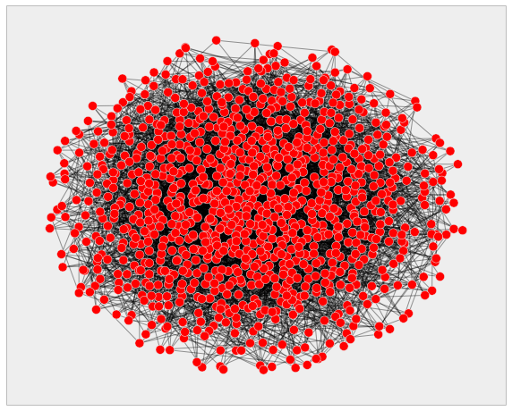

```python
fig = plt.figure(figsize=(10, 8))

# some visual styling for the figure
ax = fig.gca()
ax.grid(False)                # no grid
ax.get_xaxis().set_ticks([])  # no ticks on the axes
ax.get_yaxis().set_ticks([])

# run the spring layout algorithm over the network
pos = nx.spring_layout(er, iterations = 50, k = 2/math.sqrt(n))

# draw the network using the computed positions for the nodes
nx.draw_networkx_edges(er, pos, width = 1, alpha = 0.4)
nx.draw_networkx_nodes(er, pos, node_size=100, alpha = 1, linewidths = 0.5)
plt.show()
```

We then network the model with a certain proportion of sick individuals, with rest being susceptible:

```python
# initialise with 5% sick people
spreading_init(er)
spreading_seed(er, 0.05)
```

Finally, we create the network dynamics:

```python
# SIR model with 30% infection rate and 10% recovery rate
model = spreading_make_sir_model(0.3, 0.05)
```

### Running the model

We can now run the model:

```python
# run SIR model dynamics over the network
spreading_run(er, model, 100)
```

All well and good, but not really telling us very much. We can however enquire what percentage of the model is infected:

```python
infected = [ v for (v, attr) in er.nodes(data = True) if attr['state'] == SPREADING_RECOVERED ]
print float(len(infected)) / n
```

```
1.0
```

### Running the model as an animation

While not always useful, in this case it might be informative to run the model and show how the epidemic spreads and – in this case – dies out. We can do this by defining a function that generates an animation by changing the color of nodes according to one of their properties, and associating a colour with the two different states that a node can be in under SIR dynamics.

```python
from matplotlib import animation

def animate_discrete_property_over_graph( g, model, steps, fig, property = None, color_mapping = None, pos = None, **kwords ):
    """Draw a graph and animate the progress of a property over it. The
    property values are converted to colours that are then used to colour
    the nodes."""

    # manipulate the axes, since this isn't a data plot
    ax = fig.gca()
    ax.set_xlim([-0.2, 1.2])      # axes bounded around 1
    ax.set_ylim([-0.2, 1.2])
    ax.grid(False)                # no grid
    ax.get_xaxis().set_ticks([])  # no ticks on the axes
    ax.get_yaxis().set_ticks([])

    # if we're not given an explicit geometry, use the spring layout
    if pos == None:
        pos = nx.spring_layout(g, iterations = 50, k = 2/(math.sqrt(g.order())))

    # draw the graph, keeping hold of the node markers
    nodeMarkers = []
    for v in g.nodes_iter():
        circ = plt.Circle(pos[v], radius = 0.02, zorder = 2)   # node markers at top of the z-order
        ax.add_patch(circ)
        nodeMarkers.append({ 'node_key': v, 'marker': circ })
    for e in g.edges_iter():
        xs = [ pos[e[0]][0], pos[e[1]][0] ]
        ys = [ pos[e[0]][1], pos[e[1]][1] ]
        line = plt.Line2D(xs, ys, zorder = 1)                  # edges lower down the z-order
        ax.add_line(line)

    # initialisation colours the markers according to the current
    # state of the property being tracked
    def colour_nodes():
        for nm in nodeMarkers:
            v = nm['node_key']
            state = g.node[v][property]
            c = color_mapping[state]
            marker = nm['marker']
            marker.set(color = c)

    # initialisation coours the markers according to the current
    # state of the property being tracked
    def init():
        colour_nodes()

    # per-frame animation just iterates the model and then colours it
    # to reflect the changed property status of each node
    def frame( i ):
        spreading_step(er, model)
        colour_nodes()

    # return the animation with the functions etc set up
    return animation.FuncAnimation(fig, frame, init_func = init, frames = steps, **kwords)
```

We can then use this to visualise the progress of an SIR epidemic across a small ER network:

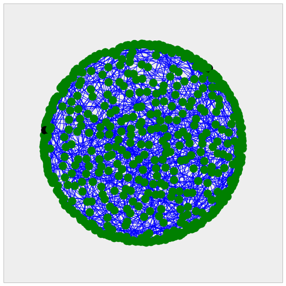

```python
# build a small ER network and an SIR model over it
er = nx.erdos_renyi_graph(500, 0.01)
spreading_init(er)
spreading_seed(er, 0.1)
model = spreading_make_sir_model(0.3, 0.05)

# animate the process, colouring infected (recovered) nodes red (green)
fig = plt.figure(figsize = (10, 10))
col = { SPREADING_SUSCEPTIBLE: 'k',
        SPREADING_INFECTED: 'r',
        SPREADING_RECOVERED: 'g' }
anim = animate_discrete_property_over_graph(er, model, 150, fig, 'state', col, interval = 50)
anim.save('er-sir.mp4')
```

It's important not to get too attached to these sorts of graphics. While they look engaging and are useful for getting the ideas straight, they're really too blunt an intstrument through which to understand the dynamics. Developing a proper understanding requires a combination of more sophisticated mathematics and more flexible analysis post-simulation.

## Analysing the model

Earlier we discussed a mathematical SIR model that use an assumption of uniform mixing to avoid dealing with the physical model of how individuals meet. We derived a system of three differential equations to model the process:

$$ \frac{ds}{dt} = -\beta i(t) s(t) \hspace{1in} \frac{di}{dt} = \beta i(t) s(t) - \alpha i(t) \hspace{1in} \frac{dr}{dt} = \alpha i(t) $$

Where $\beta$ and $\alpha$ and respectively the infection and recovery probabilities. Can we introduce a physical model into these equations to generate an analytical model of the SIR process over a network, and therefore get an analytical result to compare against our numerical results above?

Let us re-argue the definition of $\frac{ds}{dt}$ on an underlying network. We represent individuals by nodes and interactions by edges. A susceptible individual can become infected (with probability $\beta$) if they find themselves linked by an edge to an infected individual. If the node has degree $k$ then it has $k$ opportunies for infection. What is the probability that two adjacent nodes are susceptible and infected? In an ER network all pairs of nodes are equally likely to be connected to each other, so the probability is simply that two nodes taken at random and susceptible and infected, which is $s(t)i(t)$. An average node in an ER network has degree $\langle k \rangle$, so there are $\langle k \rangle$ opportunities for this conjunction of nodes to appear. Therefore we can define the rate of change for susceptible nodes as:

$$ \frac{ds}{dt} = -\beta \langle k \rangle i(t) s(t) $$

Similar arguments give the other two equations in the system:

$$ \frac{di}{dt} = \beta \langle k \rangle i(t) s(t) - \alpha i(t) \hspace{1in} \frac{dr}{dt} = \alpha i(t) $$

Notice that the expression for $\frac{dr}{dt}$ is unaffected as the rate of recovery is constant for this model: it applies to nodes individually and isn't affected by their degree or neighbours.

$$ \begin{align} s(t) &= \int -\beta \langle k \rangle i(t) s(t) \, dt \\ &= e^{-\beta \langle k \rangle r(t)} \end{align} $$

If we now waht to know how many individuals became infected over the course of the epidemic, we need to compute the value of $r(t)$ at a time when the system has stabilised and there are no longer any infected individuals left in the system. We denote this value $r_\infty$, the value of $r(t)$ at some "infinite time" $t_\infty$ of no further change. Since $i(t_\infty) = 0$ by definition, $s(t_\infty) + r_\infty = 1$, and so:

$$ r_\infty = 1 - e^{-\beta \langle k \rangle r_\infty} $$

This is a self-consistency condition – $r_\infty$ defined in terms of itself – but we can still work out its value by observing that we must have:

$$ \frac{d}{dr_\infty} \left ( 1 - e^{-\beta \langle k \rangle r_\infty} \right ) \bigg |_{r_\infty = 0} \geq 1 $$

So $\beta \geq \frac{1}{\langle k \rangle}$.